# Análise de dados exploratória de lotação

```r
init.time <- Sys.time()
library(plyr)
library(tidyverse)
library(ggmap)
```

Importando os dados:

```r
path = "/local/luiz/bigsea/pre-processed-data/training_data3"

filenames <- list.files(path, pattern = "*.csv", full.names=TRUE)
list_of_dataframes <- lapply(filenames, read.csv)
rm(filenames)
busData <- rbind.fill(list_of_dataframes)
rm(list_of_dataframes)
```

```r
busData <- busData %>% select(route, busStopIdOrig, numPassengers, probableNumPassengers, hourOrig, date, hourDest, weekDay, weekOfYear, shapeLatOrig, shapeLonOrig, duration, problem)
str(busData)
```

```
## 'data.frame':    2838282 obs. of  13 variables:
##  $ route                : int  1 1 1 1 1 1 1 1 1 1 ...
##  $ busStopIdOrig        : int  29887 31453 31454 30748 30749 35216 26166 35219 29420 29082 ...
##  $ numPassengers        : int  0 0 0 0 0 0 0 0 0 0 ...
##  $ probableNumPassengers: num  0 0 0 0 0 0 0 0 0 0 ...
##  $ hourOrig             : int  13 13 13 13 13 13 13 13 13 13 ...
##  $ date                 : Factor w/ 7 levels "2017-07-01","2017-07-02",..: 1 1 1 1 1 1 1 1 1 1 ...
##  $ hourDest             : int  13 13 13 13 13 13 13 13 13 13 ...
##  $ weekDay              : Factor w/ 7 levels "Fri","Mon","Sat",..: 3 3 3 3 3 3 3 3 3 3 ...
##  $ weekOfYear           : int  26 26 26 26 26 26 26 26 26 26 ...
##  $ shapeLatOrig         : num  -25.4 -25.4 -25.4 -25.4 -25.4 ...
##  $ shapeLonOrig         : num  -49.3 -49.3 -49.3 -49.3 -49.3 ...
##  $ duration             : int  63 65 108 11 87 153 101 146 60 50 ...
##  $ problem              : Factor w/ 4 levels "BETWEEN","NO_PROBLEM",..: 1 2 1 2 2 1 2 2 2 1 ...
```

- route : rota do ônibus
- tripNumOrig : o número da viagem do ônibus na origem
- shapeId : o id do shape do ônibus
- shapeSequence : o ponto do shape que a viagem está atualmente
- shapeLatOrig : a latitude da origem do shape
- shapeLonOrig : a longitude da origem do shape
- distanceTraveledShapeOrig: a distancia que o ônibus já viajou na origem.
- busCode : o código do ônibus
- gpsPointId : o id do ponto do gps
- gpsLat : a latitude do ponto do gps
- gpsLon : a longitude do ponto do gps
- distanceToShapePoint : a distância do gps para o ponto do shape casado
- timestampOrig : o horário no ponto de origem
- busStopIdOrig : a parada do ônibus no ponto de origem
- problem : o tipo de problema encontrado pelo BULMA que pode ser NO_PROBLEM, quando não houver problema, NO_SHAPE, quando nenhuma trip foi formada (gps sem shape na base de dados ou com pontos insuficientes para formar trip), TRIP_PROBLEM, quando não foi possível identificar ponto final/ponto inicial, OUTLIER_POINT, quando os pontos excederam o threshold de distância para o shape.
- numPassengers : a quantidade de passageiros que subiu no ônibus em determinada parada
- date : a data da viagem
- busStopIdDest : o ponto de ônibus do destino
- timestampDest : o horário no ponto de destino
- tripNumDest : o número da viagem do ônibus no destino
- shapeLatDest : a latitude do ponto do shape destino
- shapeLonDest : a longitude do ponto do shape destino
- distanceTraveledShapeDest: a distancia que o ônibus já viajou no destino
- acumPassengers : número de passageiros acumulado durante a viagem
- probableNumPassengers : número provável de passageiros durante a viagem, estimando a descida dos mesmos
- duration : a duração entre a parada origem e destino
- distance : a distancia entre a parada origem e destino
- hourOrig : a hora de origem
- hourDest : a hora de destino
- isRushOrig : indicativo se está em horário de pico na origem
- isRushDest : indicativo se está me horário de pico no destino
- periodOrig : o período na origem (manhã, tarde, noite)
- periodDest : o período no destino (manhã, tarde, noite)
- weekDay : o dia da semana
- weekOfYear : a semana do ano
- dayOfMonth : o dia do mês
- month : o mês
- isHoliday : indicativo se está em mês de férias
- isWeekend : indicativo se é final de semana
- isRegularDay : indicativo se está entre a terça e quinta inclusive

Análises posssíveis:

2. um panorama das distâncias entre as paradas
3. um panorama do número de shapes por rota
4. um panorama do número de paradas por shape
5. um panorama do tamanho dos shapes
6. Relação entre lotação entre uma parada e outra e a distância entre essas paradas
7. panorama do periodo do dia e lotação da viagem entre duas paradas
8. Panorama entre o dia da semana e a lotação da viagem entre duas paradas

analises que queremos:

1. Relação entre a hora do dia e lotação de uma viagem entre duas paradas
2. Relação entre o dia da semana e a lotação de uma viagem entre duas paradas
3. Relação entre a área da cidade e a lotação de uma viagem entre duas paradas

Vejamos primeiramente qual a quantidade de paradas que cada rota tem:

```r
gp.bus.data <- busData %>% distinct(route, busStopIdOrig) %>% group_by(route) %>% summarise(num.stops = n())

summary(gp.bus.data)
```

```
##      route         num.stops
##  Min.   :  1.0   Min.   :  3.00
##  1st Qu.:107.2   1st Qu.: 43.00
##  Median :213.5   Median : 66.00
##  Mean   :334.9   Mean   : 74.25
##  3rd Qu.:609.2   3rd Qu.: 98.75
##  Max.   :972.0   Max.   :340.00
```

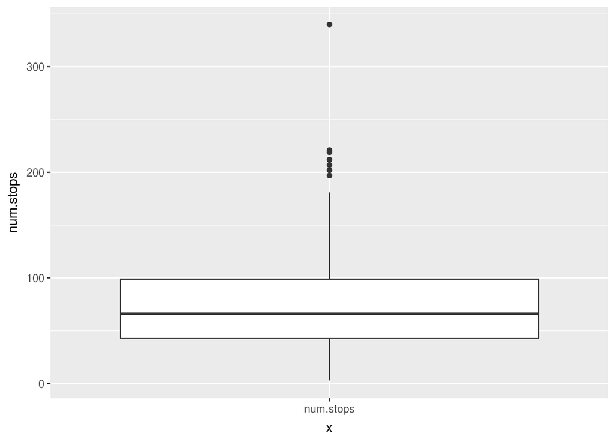

```r
ggplot(gp.bus.data, aes("num.stops", num.stops)) + geom_boxplot()
```

```r
rm(gp.bus.data)
gc()
```

```
##            used  (Mb) gc trigger   (Mb)  max used   (Mb)
## Ncells   951173  50.8    1770749   94.6   1770749   94.6
## Vcells 24595504 187.7  191876385 1464.0 239840048 1829.9
```

Vemos que a mediana é de 66 paradas, o primeiro quartil sendo 43 e o terceiro sendo 98.75 paradas.

Vejamos agora a quantidade de pessoas que sobem por paradas nas diferentes rotas:

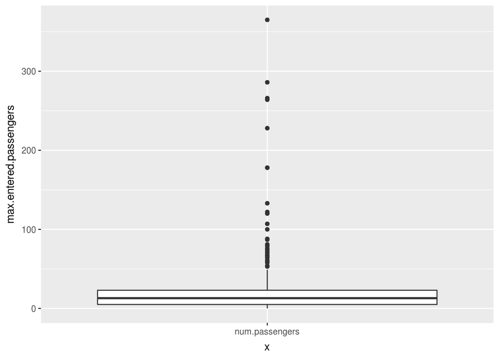

```r
gp.bus.crowdedness <- busData %>%
  group_by(route) %>%
  summarise(
    max.entered.passengers = max(numPassengers, na.rm = TRUE),
    median.entered.passengers = median(numPassengers, na.rm = TRUE),
    median.crowdedness = median(probableNumPassengers)
  )

ggplot(gp.bus.crowdedness, aes(x = "num.passengers", max.entered.passengers)) +
  geom_boxplot()
```

```r
gp.bus.crowdedness %>%
  arrange(max.entered.passengers) %>%
  head(30)
```

```
## # A tibble: 30 x 4
##    route max.entered.passengers median.entered.passengers
##    <int>                  <dbl>                     <dbl>
##  1   614                   -Inf                        NA
##  2    56                      0                         0
##  3    93                      0                         0
##  4   208                      0                         0
##  5   210                      0                         0
##  6   302                      0                         0
##  7   303                      0                         0
##  8   304                      0                         0
##  9   305                      0                         0
## 10   307                      0                         0
## # ... with 20 more rows, and 1 more variables: median.crowdedness <dbl>
```

Vemos que existem muitas rotas que não entram pessoas no ônibus. Com isso, vamos filtrar as rotas que não entram pessoas:

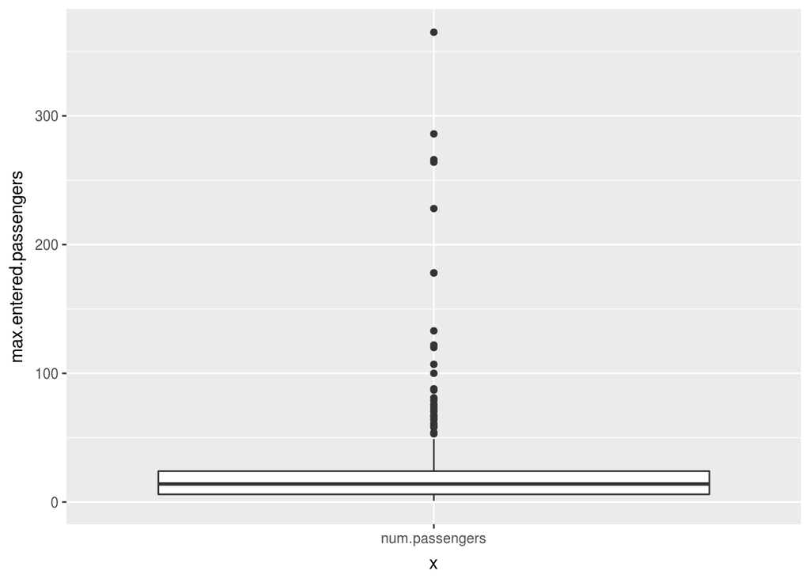

```r
gp.bus.crowdedness.positive.passengers <- gp.bus.crowdedness %>%
  filter(max.entered.passengers > 0)

  ggplot(gp.bus.crowdedness.positive.passengers, aes(x = "num.passengers", max.entered.passengers)) +
    geom_boxplot()
```

```r
rm(gp.bus.crowdedness)
gc()
```

```
##            used  (Mb) gc trigger   (Mb)  max used   (Mb)
## Ncells   971064  51.9    1770749   94.6   1770749   94.6
## Vcells 24650023 188.1  153501108 1171.2 239840048 1829.9
```

Apesar de uma pequena diferença, vamos prosseguir na filtragem:

```r
bus.data.filt <- busData %>%
  filter(route %in% gp.bus.crowdedness.positive.passengers$route)

rm(gp.bus.crowdedness.positive.passengers)
rm(busData)
gc()
```

```
##            used  (Mb) gc trigger  (Mb)  max used   (Mb)
## Ncells   954213  51.0    1770749  94.6   1770749   94.6
## Vcells 22956682 175.2  122800886 936.9 239840048 1829.9
```

Agora iremos verificar a distribuição da quantidade de passageiros que subiram em um ônibus em uma parada, fornercida pelo BULMA.

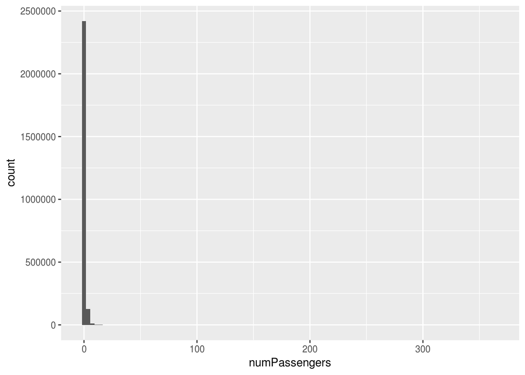

```r
ggplot(bus.data.filt, aes(numPassengers)) +
  geom_histogram(bins = 100)
```

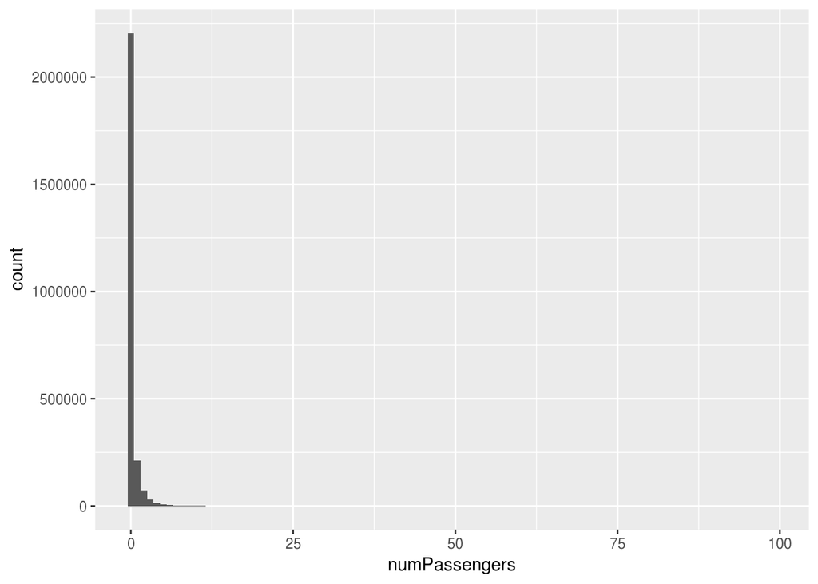

```r
bus.data.filt2 <- bus.data.filt %>%
  filter(numPassengers<100)

ggplot(bus.data.filt2, aes(numPassengers)) +
  geom_histogram(bins = 100)
```

```r
rm(bus.data.filt2)
gc()
```

```
##            used  (Mb) gc trigger  (Mb)  max used   (Mb)
## Ncells   977916  52.3    1770749  94.6   1770749   94.6
## Vcells 43498337 331.9  122800886 936.9 239840048 1829.9
```

Vemos que existem muitas rotas em que a quantidade de passageiros que subiram no ônibus em determinada parada é próxima de zero.

## Hora do dia

Agora vamos plotar um gráfico de lotação de viagens entre paradas por horas do dia.

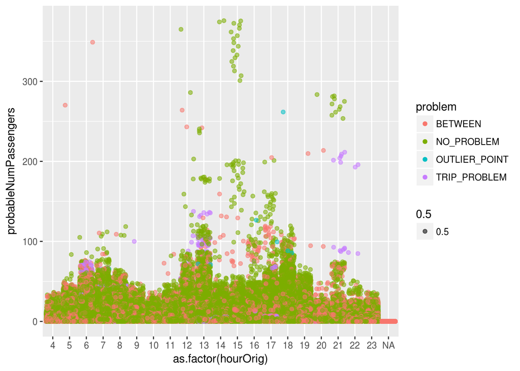

```r
ggplot(bus.data.filt, aes(x = as.factor(hourOrig), y = probableNumPassengers, colour = problem)) +
  geom_jitter(aes(alpha = 0.5))
```

Podemos perceber que muitas viagens têm lotação baixa, mas também existem uma grande quantidade de quantidade de passageiros com valores consideráveis e outros que parecem ser outliers.

Vejamos outra visualização para que fique mais nítido:

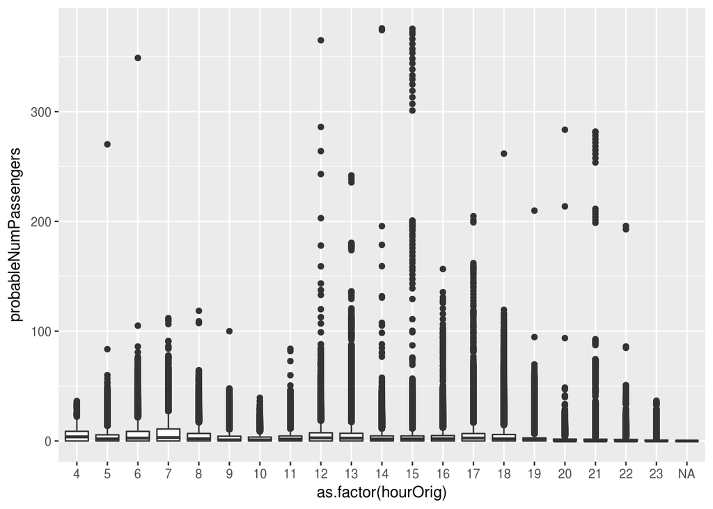

```r
ggplot(bus.data.filt, aes(x = as.factor(hourOrig), y = probableNumPassengers)) +
  geom_boxplot()
```

Podemos ver que grande parte do tempo os ônibus permanecem vazios, ou com poucas pessoas. Talvez isso indique que as pessoas andem mais paradas dentro do ônibus do que o algoritmo de pre-processamento esta estimando. Em compensação existem valores muito altos, onde o maior chega a mais de 300, que é um erro gerado pela estimativa.

Vamos ver se o problema das viagens identificado pelo BULMA tem relação com a quantidade provável de passageiros:

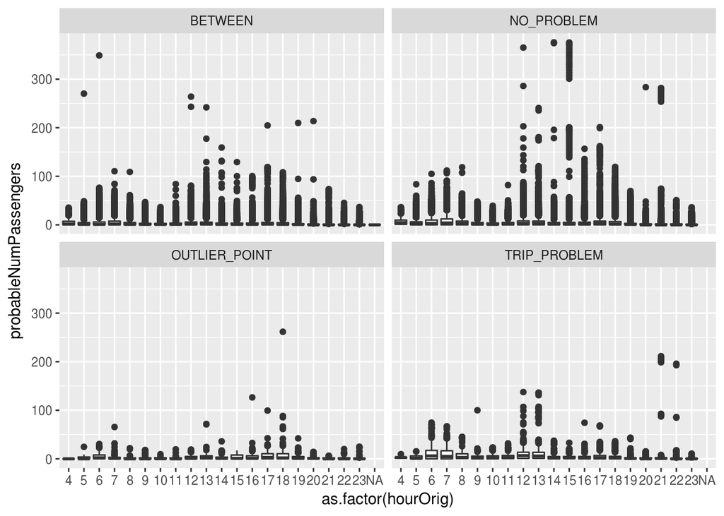

```r
ggplot(bus.data.filt, aes(x = as.factor(hourOrig), y = probableNumPassengers)) +
  geom_boxplot() +
  facet_wrap(~problem)
```

Podemos verificar que a quantidade de passageiros dentro do ônibus continua pequena, mesmo separando os tipos de problema das viagens identificados pelo BULMA.

Vejamos a mediana da quantidade provável de passageiros por hora do dia:

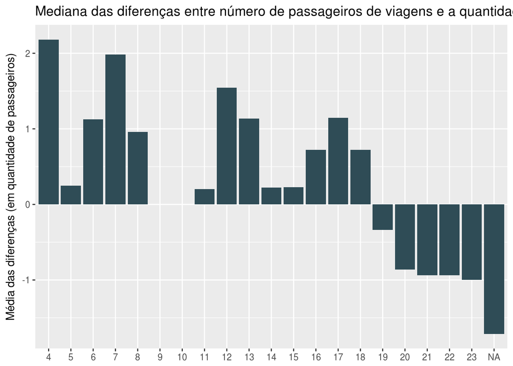

```r
summarised.dates <- bus.data.filt %>% group_by(date) %>%
  summarise(meanCrowdedness = mean(probableNumPassengers),
            medianCrowdedness = median(probableNumPassengers))

temp1 <- bus.data.filt %>% select(date, hourOrig, hourDest, probableNumPassengers)
temp1 <- left_join(temp1, summarised.dates, by = "date")
rm(summarised.dates)

temp1 <- temp1 %>% mutate(
  diffFromMedian = probableNumPassengers - medianCrowdedness
)

temp2 <- temp1 %>% group_by(hourOrig) %>%
  summarise(
   medianOfDiffs = median(diffFromMedian)
)
rm(temp1)

ggplot(temp2, aes(as.factor(hourOrig), medianOfDiffs)) +
  geom_bar(stat = "identity", fill = "#2f4c56", legend = FALSE) +
  scale_y_continuous("Média das diferenças (em quantidade de passageiros)") +
  theme(axis.title.x = element_blank()) +
  labs(title = "Mediana das diferenças entre número de passageiros de viagens e a quantidade de passageiros mediana do dia")
```

```r
rm(temp2)
gc()
```

```
##            used  (Mb) gc trigger  (Mb)  max used   (Mb)
## Ncells  1003844  53.7    1770749  94.6   1770749   94.6
## Vcells 23036685 175.8  117952850 900.0 239840048 1829.9
```

Vemos que existe um pico logo no início da manhã sobre a quantidade de passageiros, o qual tem um retorno perto do meio dia e final da tarde.

## Dia da semana

Vejamos se a lotação é influenciada pelos dias da semana

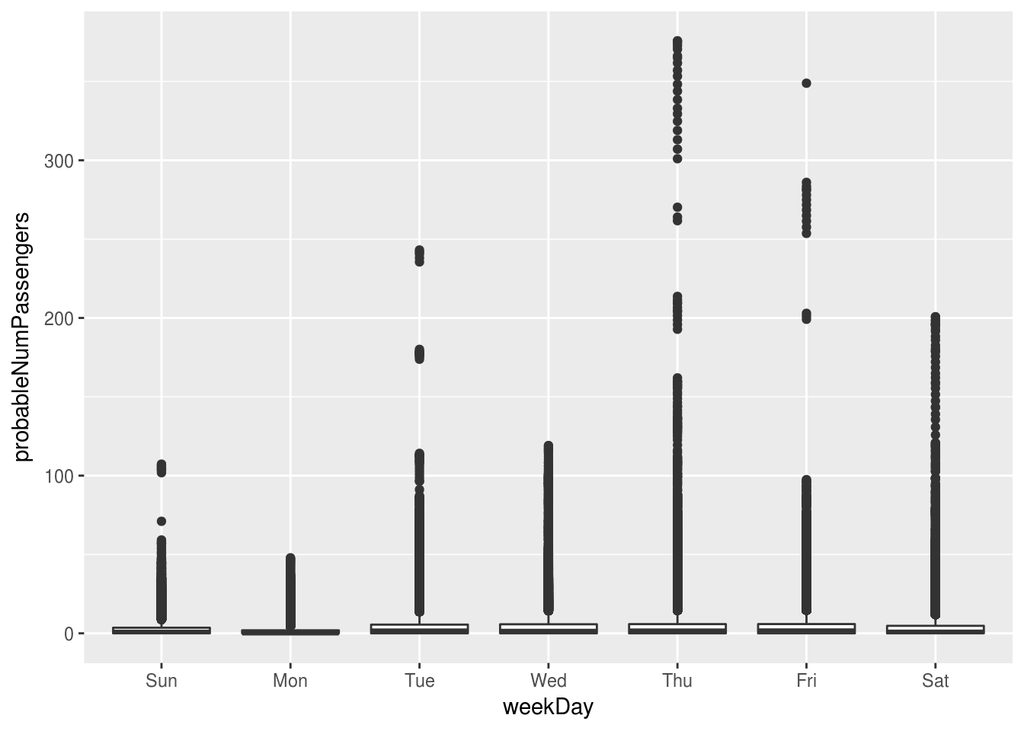

```r
bus.data.filt <- bus.data.filt %>%
  mutate(
    weekDay = factor(weekDay, levels = c("Sun", "Mon", "Tue", "Wed", "Thu", "Fri", "Sat"))
  )

ggplot(bus.data.filt, aes(x = weekDay, y = probableNumPassengers)) +
  geom_boxplot()
```

Vemos que os dias não parecem influenciar a quantidade mediana de passageiros.

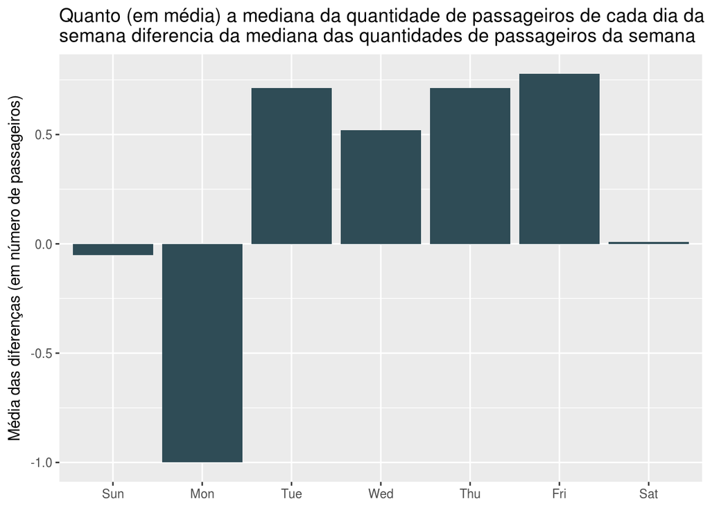

```r
summarised.weeks <- bus.data.filt %>% group_by(weekOfYear) %>%
  summarise(medianWeek = median(probableNumPassengers))

temp3 <- bus.data.filt %>% select(weekOfYear, weekDay, probableNumPassengers)
temp3 <- left_join(temp3, summarised.weeks, by = "weekOfYear")
rm(summarised.weeks)

temp3 <- temp3 %>% mutate(
  diffFromMedian = probableNumPassengers - medianWeek
)

temp4 <- temp3 %>% group_by(weekDay) %>%
  summarise(
   medianOfDiffs = median(diffFromMedian)
)
rm(temp3)

temp4 %>%
  mutate(weekDay = factor(weekDay, levels = c("Sun", "Mon", "Tue", "Wed", "Thu", "Fri", "Sat"))) %>%
  arrange(weekDay) %>%
  ggplot(aes(as.factor(weekDay), medianOfDiffs)) +
    geom_bar(stat = "identity", fill = "#2f4c56", legend = FALSE) +
    scale_y_continuous("Média das diferenças (em número de passageiros)") +
    theme(axis.title.x = element_blank()) +
    labs(title = "Quanto (em média) a mediana da quantidade de passageiros de cada dia da \nsemana diferencia da mediana das quantidades de passageiros da semana")
```

```r
rm(temp4)
gc()
```

```
##            used  (Mb) gc trigger  (Mb)  max used   (Mb)
## Ncells  1004022  53.7    1770749  94.6   1770749   94.6
## Vcells 23037113 175.8   75489824 576.0 239840048 1829.9
```

Vemos que a segunda feira é o dia que mais se diferencia, tendo a menor quantidade de passageiros da semana.

## Área da cidade

```r
m <- get_map("Curitiba",zoom=11,maptype="toner",source="stamen")

g <- ggmap(m)
rm(m)
gc()
```

```
##            used  (Mb) gc trigger  (Mb)  max used   (Mb)
## Ncells  1004673  53.7    1770749  94.6   1770749   94.6
## Vcells 23419727 178.7   75489824 576.0 239840048 1829.9
```

```r
lat.min <- -25.67
lat.max <- -25.32
lon.min <- -49.40
lon.max <- -49.07

lat.step <- (lat.max - lat.min) / 50
lon.step <- (lon.max - lon.min) / 50

bus.data.grid <- bus.data.filt %>%
  mutate(
    lat.grid.index = floor((shapeLatOrig - lat.min) / lat.step),
    lon.grid.index = floor((shapeLonOrig - lon.min) / lon.step)
  )
```

Vejamos a quantidade de passageiros mediana em um mapa:

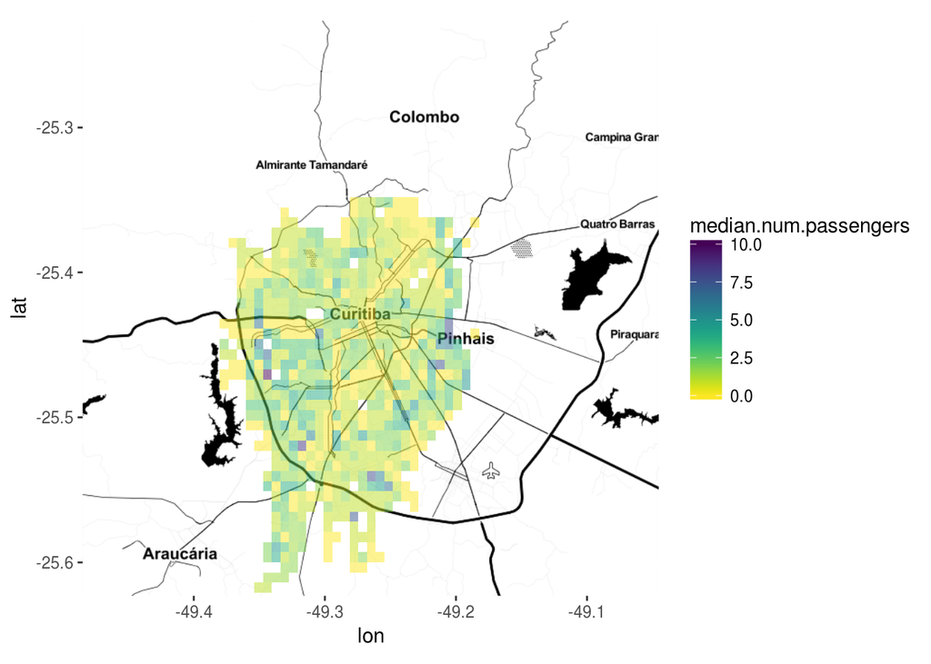

```r
bus.data.grid <- bus.data.grid %>%
  mutate(
    plotting.lat = lat.min + (lat.grid.index * lat.step + (lat.grid.index + 1) * lat.step) / 2,
    plotting.lon = lon.min + (lon.grid.index * lon.step + (lon.grid.index + 1) * lon.step) / 2
  )

summarised.grid <- bus.data.grid %>%
  group_by(plotting.lat, plotting.lon) %>%
  summarise(
    median.num.passengers = median(probableNumPassengers)
  )

g +
  geom_tile(aes(x = plotting.lon, y = plotting.lat, fill = median.num.passengers), data = summarised.grid, alpha = 0.5) +
  viridis::scale_fill_viridis(direction = -1)
```

Vamos atenuar os valores maiores para verificar a região que tem maior concentração de passageiros:

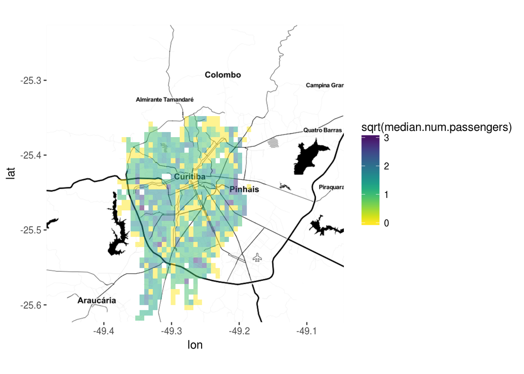

```r
g +
  geom_tile(aes(x = plotting.lon, y = plotting.lat, fill = sqrt(median.num.passengers)), data = summarised.grid, alpha = 0.5) +
  viridis::scale_fill_viridis(direction = -1)
```

```r
summarised.grid <- NULL
```

Vejamos o quanto que esses trechos se diferenciam da mediana durante a semana:

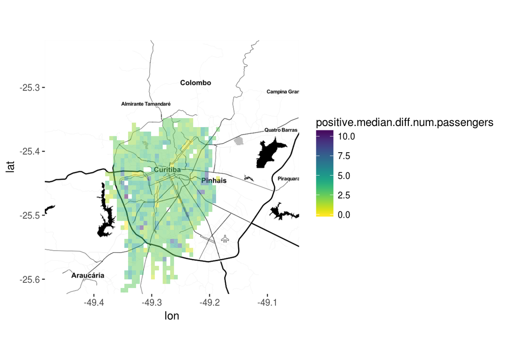

```r
hour.median.num.passengers <- bus.data.filt %>%
  group_by(hourOrig) %>%
  summarise(
    median.num.passengers = median(probableNumPassengers)
  )

joined.grid <- left_join(bus.data.grid, hour.median.num.passengers, by = "hourOrig") %>%
  mutate(diff.num.passengers = probableNumPassengers - median.num.passengers)

rm(hour.median.num.passengers)
rm(bus.data.grid)

hourly.summarised.joined.grid <- joined.grid %>%
  group_by(plotting.lat, plotting.lon) %>%
  summarise(
    median.diff.num.passengers = median(diff.num.passengers)
  )

rm(joined.grid)

min.median.diff.num.passengers <- min(hourly.summarised.joined.grid$median.diff.num.passengers)

hourly.summarised.joined.grid <- hourly.summarised.joined.grid %>%
  mutate(
    positive.median.diff.num.passengers = median.diff.num.passengers + abs(min.median.diff.num.passengers)
  )

g +
  geom_tile(aes(x = plotting.lon, y = plotting.lat, fill = positive.median.diff.num.passengers), data = hourly.summarised.joined.grid, alpha = 0.5) +
  viridis::scale_fill_viridis(direction = -1)
```

```r
gc()
```

```
##            used  (Mb) gc trigger  (Mb)  max used   (Mb)
## Ncells  1089133  58.2    1770749  94.6   1770749   94.6
## Vcells 24429712 186.4   72534230 553.4 239840048 1829.9
```

Como os corredores da cidade tem valores de duração alto e de lotação baixos, vejamos se existe uma correlação entre a duração e lotação:

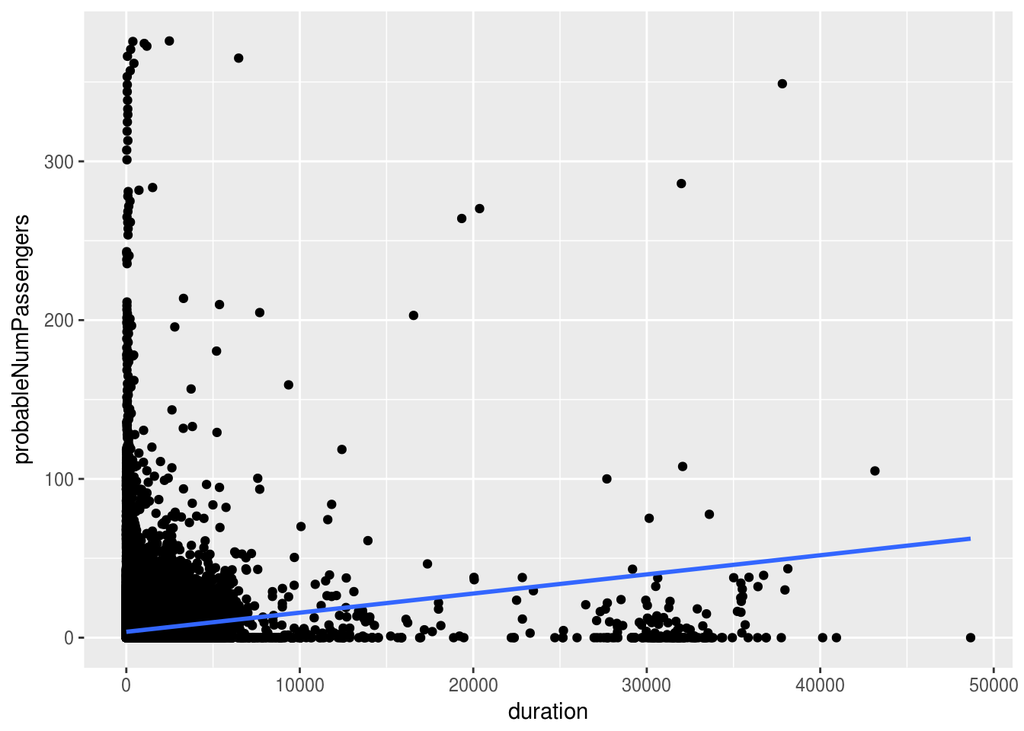

```r
ggplot(bus.data.filt, aes(x = duration, y = probableNumPassengers)) +
  geom_point() +
  geom_smooth(method = "lm")
```

Vamos filtrar os valores entre o 5 percentil e o 95 percentil:

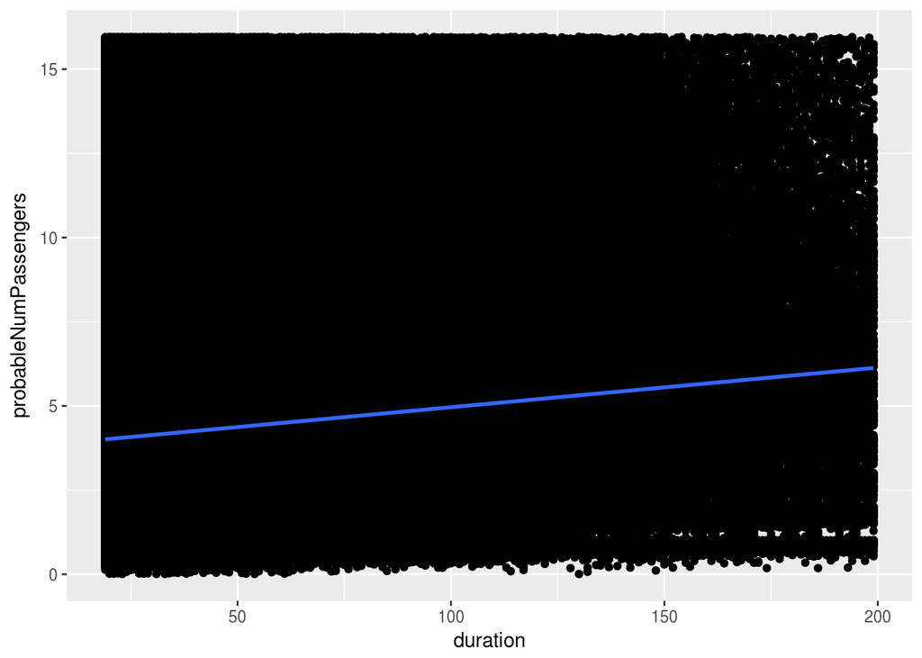

```r
duration.percentiles <- quantile(bus.data.filt$duration, c(.05, .95), na.rm = TRUE)
passengers.percentiles <- quantile(bus.data.filt$probableNumPassengers, c(.05, .95), na.rm = TRUE)

bus.data.filt <- bus.data.filt %>%
  filter(
    duration > duration.percentiles[1],
    duration < duration.percentiles[2],
    probableNumPassengers > passengers.percentiles[1],
    probableNumPassengers < passengers.percentiles[2]
  )

ggplot(bus.data.filt, aes(x = duration, y = probableNumPassengers)) +
  geom_point() +
  geom_smooth(method = "lm")
```

```r
d2 <- bus.data.filt %>%
  select(duration, probableNumPassengers) %>%
  mutate(
    lg.duration = log(duration),
    lg.probableNumPassengers = log(probableNumPassengers)
    ) %>%
  filter(
    !is.nan(lg.duration) &
      !is.nan(lg.probableNumPassengers) &
      !is.na(lg.duration) &
      !is.na(lg.probableNumPassengers) &
      !is.infinite(lg.duration) &
      !is.infinite(lg.probableNumPassengers)
    )
cor(d2$lg.duration, d2$lg.probableNumPassengers)
```

```
## [1] 0.114139
```

```r
rm(d2)
rm(bus.data.filt)
gc()
```

```
##            used  (Mb) gc trigger  (Mb)  max used   (Mb)
## Ncells  1061778  56.8    3109233 166.1   3608991  192.8
## Vcells 30777594 234.9   96535307 736.6 239840048 1829.9
```

Vemos que não existe correlação significativa entre a duração e a quantidade de passageiros.

```r
final.time <- Sys.time()
running.time <- as.character(final.time - init.time)
write.csv(running.time, "runningtime.csv", row.names = F)
```